# ridge_line_plots

Barry DeCicco

6/18/2021

## Ridgeline Plots:

(from: https://statisticsglobe.com/ridgeline-plots-in-r)

This tutorial demonstrates how to create a ridgeline plot in the R programming language.

#### Example Data:

```r
set.seed(1992)                                       # Set seed for reproducibility
example <- data.frame(day = 0, month = 0, temperature = 0)  # Create empty data

months_averages <- c(10, 11, 14, 18, 23, 26, 29, 32, 25 ,18, 14, 6)
months_sd <- c(3, 3, 4, 6, 7, 8, 5, 5, 4, 7, 4, 3)

for(i in 1:12) {                                     # Fill up data with random numbers
  example[(i*30 - 29):(i*30), "day"] <-
    1:30
  example[(i*30 - 29):(i*30), "month"] <-
    month.name[i]
  example[(i*30 - 29):(i*30), "temperature"] <-
    rnorm(n = 30,
          mean = months_averages[i],
          sd = months_sd[i]) %>%
    round()
}

example$month <-                                     # Convert month variable into a factor
  example$month %>%
  as_factor()

head(example)
```

```
##   day   month temperature
## 1   1 January          11
## 2   2 January          13
## 3   3 January          10
## 4   4 January           7
## 5   5 January          11
## 6   6 January           5
```

## Alternatives to Ridgeline Plots

The typical alternative to ridgeline plots would be histograms. We could create an overlaid ggplot2 histogram of our example data using the following lines of code:

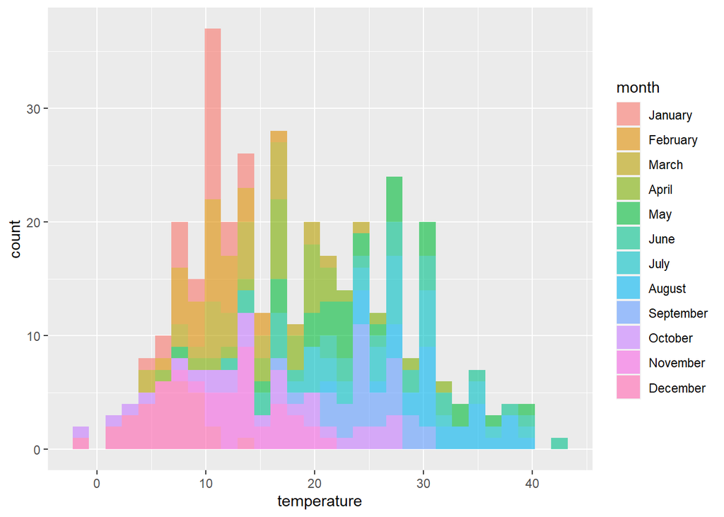

```r
histogram <-                                         # Draw histogram
  example %>%
  ggplot(aes( x = temperature, fill = month)) +
  geom_histogram( alpha = 0.6)
histogram
```

#### Faceted Histograms:

Figure 1 shows the output of the previous R syntax. All the histograms were drawn together, what a mess!

Another alternative would be a facet plot where we facet against months to see every histogram in a separate panel:

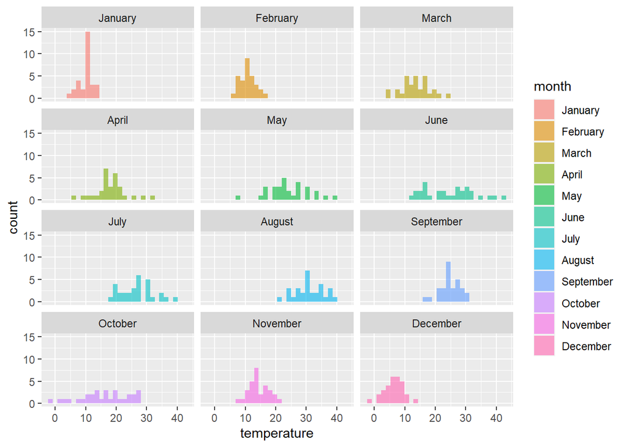

```r
faceted_histogram <-                                 # Draw facet plot
  histogram +
  facet_wrap(~ month, nrow = 4)
faceted_histogram
```

Figure 2 shows our data in a facet plot. This already looks much better. However, an even cleaner way to visualize our data would be ridgeline plots.

We’ll draw such graphs in the next sections – so keep on reading!

#### Example 1: Drawing Ridgeline Plot of Histograms:

If we want to create ridgeline graphics in R, we first have to install and load the ggridges package:

```r
# install.packages("ggridges")   # already installed
# library("ggridges")            #
```

We can now use the geom_density_ridges function to draw the histograms in a ridgeline chart. In our plot, the x aesthetic will be the temperature. The y aesthetic will be the months, since we want to have each month separated.

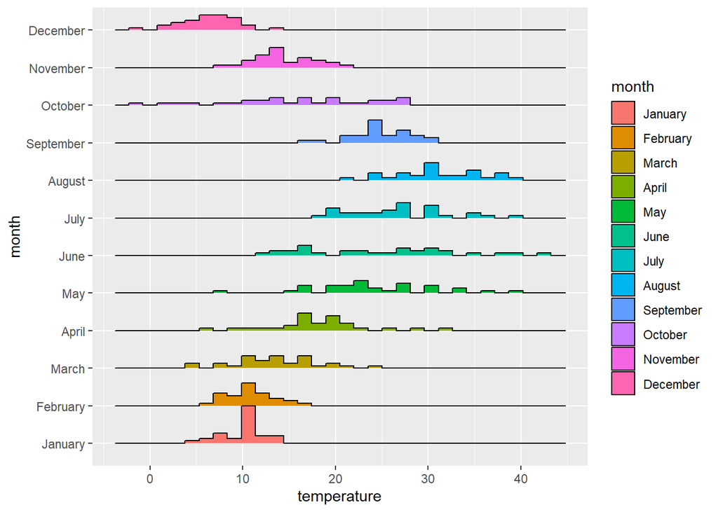

```r
ridge_histogram_plot <-                              # Draw histograms in ridgeline plot
  example %>%
  ggplot(aes(x = temperature , y = month,  fill = month)) +
  ggridges::geom_density_ridges(scale = 1,           # Overlap among histograms
                                stat = "binline")
ridge_histogram_plot
```

#### Example 2: Drawing Ridgeline Plot of Densities

We can also make density plots instead of histograms by removing stat = “binline” within the geom_density_ridges function:

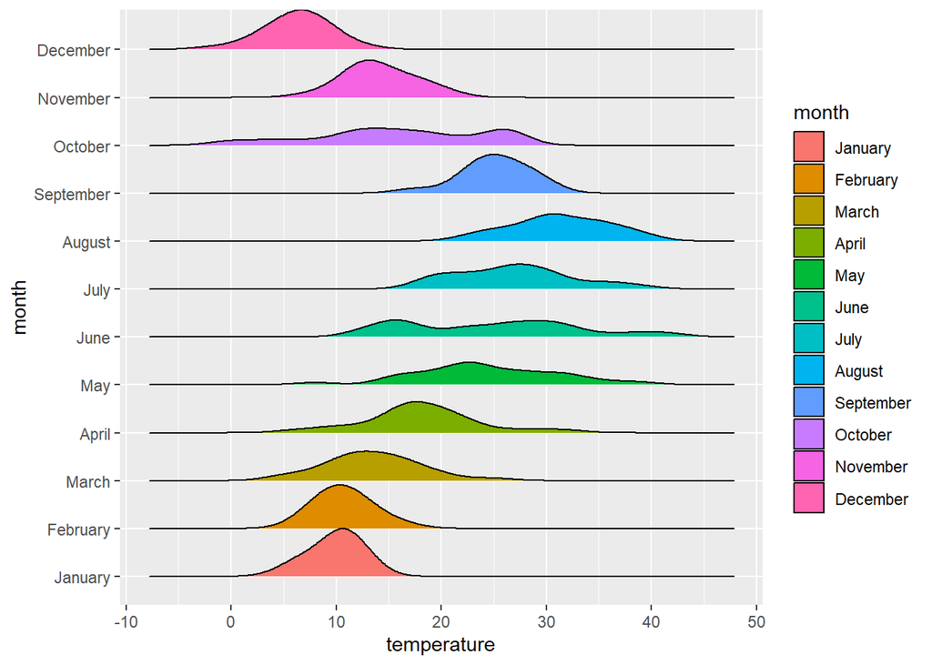

```r
ridge_density_plot <-           # Draw densities in ridgeline plot
  example %>%
  ggplot(aes(x = temperature , y = month,  fill = month)) +
  ggridges::geom_density_ridges(scale = 1)           # Overlap among histograms
ridge_density_plot
```

As you can see in Figure 4, our histograms were replaced by densities.

#### Example 3: Modifying the Groups in Ridgeline Plots

We can also use ridgeline charts to draw the same group (i.e. seasons instead of months) over several lines in our graphic.

For this, we first have to add another variable to our data, which converts our month variable into seasons:

```r
example$season <-        # Add seasons to better see the group of months
  case_when(example$month %in% month.name[c(12, 1, 2)] ~ "Winter",
            example$month %in% month.name[c(3:5)] ~ "Spring",
            example$month %in% month.name[c(6:8)] ~ "Summer",
            example$month %in% month.name[c(9:11)] ~ "Autumn" ) %>%
  as_factor()
head(example)
```

```
##   day   month temperature season
## 1   1 January          11 Winter
## 2   2 January          13 Winter
## 3   3 January          10 Winter
## 4   4 January           7 Winter
## 5   5 January          11 Winter
## 6   6 January           5 Winter
```

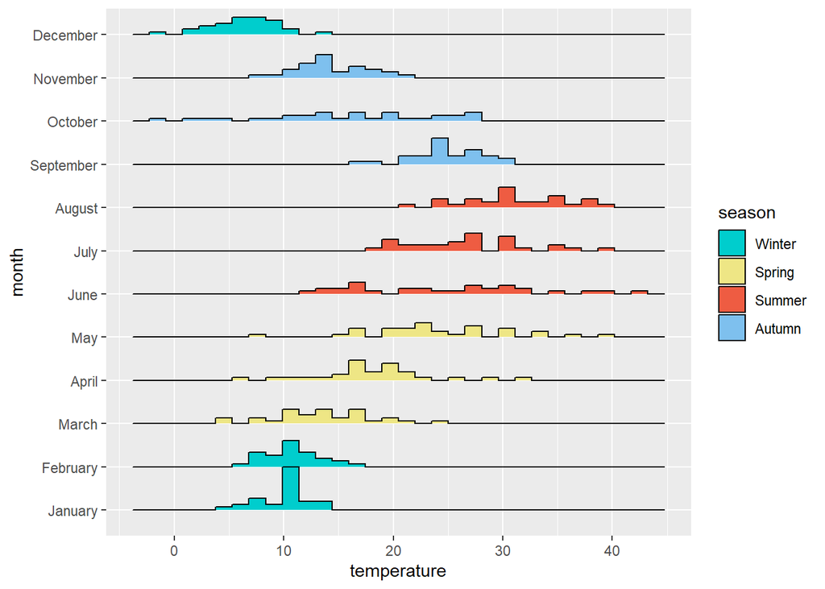

```r
ridge_histogram_by_season <-                         # Ridgeline plot with seasons
  example %>%
  ggplot(aes(x = temperature , y = month,  fill = season)) +
  ggridges::geom_density_ridges(scale = 1,           # Overlap among histograms
                                stat = "binline") +  # Draw histograms
  scale_fill_manual(values = c("cyan3",
                               "khaki2",
                               "tomato2",
                               "skyblue2"))
ridge_histogram_by_season
```

Figure 5 shows our final plot with colors corresponding to the seasons of the year. Note that the histograms shown in this ridgeline plot are the same as in Figure 3.